# Day 24 - Package Documentation

Spring 2023

[Dr. Jared Joseph](https://jnjoseph.com/)

Smith College

## Overview

### Timeline

- Help Files Overview
- Writing Help Files

### Goal

Learn how to author help files and make them usable in R.

# Help Files Overview

## What Does a Help File Include?

**Title**

What is the title of the help page? (Usually a tiny description of function)

**Description**

What does this function do?

**Arguments**

What arguments does the function take? What are the defaults? What type of objects work?

**Details**

What else do you want people to know?

**Return**

What does the function return?

**Examples**

What are some examples of using this function?

## Help Files live in `./man/`

The `man` directory contains all of the help files for your code.

These are the files loaded when using the `?` or `help()` function in R.

You need to write them, but we have tools to help with the formatting later.

```
R Project Name
```

```r
.
├── R/
│   └── func1.R
├── man/
│   └── func1.Rd
├── inst/
│   ├── data/
│   │   └── example_data1.csv
│   └── other
├── vignettes/
│   └── v1.rmd
├── docs/
│   └── v1.html
├── tests/
│   └── testthat/
│       └── test-func1.R
├── NAMESPACE
├── DESCRIPTION
├── LICENSE
├── NEWS.md
├── README.Rmd
├── .gitignore
└── .Rbuildignore
```

# Writing Help Files

## The `.rd` Syntax

R help files rely on a specific syntax unique to R.

It’s like `LaTeX`, but not quite. You can see an example here.

By using specific formats, we can do things like link to other help files, and have executable examples.

```r
\name{nattswap_compare}
\alias{nattswap_compare}
\title{nattswap_compare}
\usage{
nattswap_compare(
  get_att_swap_sig_results,
  metric_name = "all",
  swapped_att,
  all_nrow = 1,
  all_ncol = NULL,
  font_family = NULL,
  yaxis = c(NA, NA),
  xaxis = NA,
  bin_num = 50
)
}
\arguments{
\item{get_att_swap_sig_results}{Result of \code{get_att_swap_sig}}

\item{metric_name}{Character. A vector of "degree", "evc", "bet", "n_bet", "closeness", "max_cohesion", or "nestedness". Defaults to "all" which will display all metrics.}

...
```

## `roxygen2` Templates

Rather than write help files ourselves, we’ll use `roxygen2` to help.

This package lets us write the documentation for functions along side the code, and simplifies the syntax a bit.

You can see an example template here.

```r
#' nattswap_compare
#'
#' @param get_att_swap_sig_results Result of \code{get_att_swap_sig}
#' @param metric_name Character. A vector of "degree", "evc", "bet", "n_bet", "closeness", "max_cohesion", or "nestedness". Defaults to "all" which will display all metrics.
#' @param swapped_att Character. Name of swapped attribute.
#' @param all_nrow How many rows do you want the plot to have?
#' @param all_ncol How many columns do you want the plot to have?
#' @param font_family Font family to use in plots.
#' @param yaxis Vector of 2 integers. Lower and upper limit of y axis.
#' @param xaxis List of with element names matching plot types \(e.g. degree\). List contains length 2 vectors specifying x axis limits for plot of that type.
#' @param bin_num The number of bins you want in the histograms.
#'
#' @return A ggplot2 plot showing real vs simulated means
#' @export
```

## Elements of a RO2 Template

**Title**

The first line of your template

**Description**

Anything between the `@description` tag and the next tag.

**Arguments**

Each argument needs it’s own `@param` tag.

**Details**

Anything between the `@details` tag and the next tag.

**Return**

Anything after the `@returns` tag

**Examples**

The rest of the template after the `@examples` tag.

**Export**

The end of every template should include the `@export` tag if you want users to find it

## Special Formatting

The tags on the last slide are used to define sections in the help file.

There are also a few other special formatting tricks.

- Ticks ` ` can be put around text to make look like code.
- Square brackets `[]` can be put around the name of a function to link to the corresponding help file.

```r
#' Title Here
#'
#' @description
#' Here I describe the function
#'
#' @param x What is x?
#' @param y What is y?
#'
#' @details
#' Other details about the function
#' Similar to [sum()]
#'
#' @returns The sum of `x` + `y`
#'
#' @export
#'
#' @examples
#' result <- my_func(1, 5)
my_func <- function(x, y){return(sum(x, y))}
```

## A Note on Examples

While most sections of a help file are just text, the examples need to be actual R code that can be executed and must never error.

This presents a dilemma. Your example code needs to be both:

- Complex are realistic enough to be helpful
- Simple enough to be run with no side effects or complex dependencies.

This will work:

```r
#' @examples
#' result <- my_func(1, 5)
my_func <- function(x, y){return(sum(x, y))}
```

These will break your entire package:

```r
#' @examples
#' result <- my_func(1, "a")
#' result <- my_fish(1, 5)
my_func <- function(x, y){return(sum(x, y))}
```

## Making the `.rd` Files

Once you have written your function and it’s documentation, you can use the `devtools::document()` function to convert your template into a real help page file.

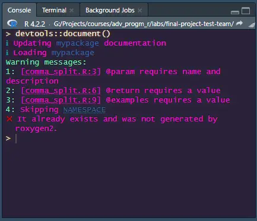

You have to remember to run it though! You can re-run it at any time to update changes.

# Code-Along

## For Next Time

### Topic

Lab 6

### To-Do

- Finish Worksheet

SDS 270: Advanced Programming for Data Science